# ST MOB data analysis

Xiao Zhang

2025-04-01

This vignette introduces the CAESAR.Suite workflow for the analysis of MOB ST spatial transcriptomics dataset. In this vignette, the workflow of CAESAR.Suite consists of four steps

- Reference dataset and target dataset preprocessing
- Detect signature genes as cell type markers from scRNA-seq reference data
- Annotate MOB ST data using CAESAR
- Downstream analysis (i.e. , signature gene analysis, visualization of cell types and coembeddings)

## Load and quality control both reference and target data

We demonstrate the use of CAESAR to MOB data, which can be downloaded and load to the current working path by the following command:

```r
githubURL <- "https://github.com/XiaoZhangryy/CAESAR.Suite/blob/master/vignettes_data/MOB_ST.rda?raw=true"
MOB_ST_file <- file.path(tempdir(), "MOB_ST.rda")
download.file(githubURL, MOB_ST_file, mode='wb')
load(MOB_ST_file)

print(MOB_ST)
```

```
#> An object of class Seurat
#> 16034 features across 282 samples within 1 assay
#> Active assay: RNA (16034 features, 0 variable features)
#>  2 layers present: counts, data
```

```r
githubURL <- "https://github.com/XiaoZhangryy/CAESAR.Suite/blob/master/vignettes_data/MOB_scRNA.rda?raw=true"
MOB_scRNA_file <- file.path(tempdir(), "MOB_scRNA.rda")
download.file(githubURL, MOB_scRNA_file, mode='wb')
load(MOB_scRNA_file)

print(MOB_scRNA)
```

```
#> An object of class Seurat
#> 18560 features across 12801 samples within 1 assay
#> Active assay: RNA (18560 features, 0 variable features)
#>  2 layers present: counts, data
```

The package can be loaded with the command:

```r
set.seed(1) # set a random seed for reproducibility.
library(CAESAR.Suite) # load the package of CAESAR method
library(Seurat)
library(ProFAST)
```

```r
library(ggplot2)
```

Users can perform appropriate quality control on the reference dataset and target data. Genes expressed in less than one cell are required to remove to avoid unknown errors. Other quality control steps can be set by the user according to the data quality. Here, cells with less than five genes and genes expressed in less than one cell were excluded.

```r
MOB_ST <- CreateSeuratObject(
    counts = MOB_ST@assays$RNA@counts,
    meta.data = MOB_ST@meta.data,
    min.features = 5,
    min.cells = 1
)

print(MOB_ST)
```

```
#> An object of class Seurat
#> 16034 features across 280 samples within 1 assay
#> Active assay: RNA (16034 features, 0 variable features)
#>  1 layer present: counts
```

```r
MOB_scRNA <- CreateSeuratObject(
    counts = MOB_scRNA@assays$RNA@counts,
    meta.data = MOB_scRNA@meta.data,
    min.features = 5,
    min.cells = 1
)

print(MOB_scRNA)
```

```
#> An object of class Seurat
#> 17812 features across 12801 samples within 1 assay
#> Active assay: RNA (17812 features, 0 variable features)
#>  1 layer present: counts
```

## Preprocessing and align reference and target data

First, we normalize the data and select the variable genes. We align genes and variable genes of reference and target data.

```r
# align genes
common_genes <- intersect(rownames(MOB_ST), rownames(MOB_scRNA))
MOB_ST <- MOB_ST[common_genes, ]
MOB_scRNA <- MOB_scRNA[common_genes, ]

print(length(common_genes))
```

```
#> [1] 13895
```

```r
MOB_ST <- NormalizeData(MOB_ST)
```

```
#> Normalizing layer: counts
```

```r
MOB_ST <- FindVariableFeatures(MOB_ST, nfeatures = 2000)
```

```
#> Finding variable features for layer counts
```

```r
MOB_scRNA <- NormalizeData(MOB_scRNA)
```

```
#> Normalizing layer: counts
```

```r
MOB_scRNA <- FindVariableFeatures(MOB_scRNA, nfeatures = 2000)
```

```
#> Finding variable features for layer counts
```

```r
common_vgs <- intersect(VariableFeatures(MOB_ST), VariableFeatures(MOB_scRNA))
VariableFeatures(MOB_ST) <- common_vgs
VariableFeatures(MOB_scRNA) <- common_vgs

print(length(common_vgs))
```

```
#> [1] 508
```

## Detect signature genes for each cell type using scRNA-seq reference data

We introduce how to use CAESAR to detect signature genes form scRNA-seq reference data. First, we calculate the co-embeddings.

```r
MOB_scRNA <- ProFAST::NCFM(MOB_scRNA, q = 50)
```

Then, we detect signature genes.

```r
# calculate cell-gene distance
MOB_scRNA <- ProFAST::pdistance(MOB_scRNA, reduction = "ncfm")
```

```
#> Calculate co-embedding distance...
```

```r
# identify signature genes
print(table(MOB_scRNA$CellType))
```

```
#>
#> EPL-IN     GC   M/TC   OSNs    PGC
#>    161   8614   1133   1200   1693
```

```r
Idents(MOB_scRNA) <- MOB_scRNA$CellType
sg_sc_List <- find.sig.genes(MOB_scRNA)

str(sg_sc_List)
```

```
#> List of 5
#>  $ EPL-IN:'data.frame':  13895 obs. of  5 variables:
#>   ..$ distance        : num [1:13895] 0.0672 0.0676 0.0677 0.0678 0.0678 ...
#>   ..$ expr.prop       : num [1:13895] 0.0559 0.0807 0.0932 0.0621 0.0683 ...
#>   ..$ expr.prop.others: num [1:13895] 0.000791 0.001503 0.000712 0.001503 0.005696 ...
#>   ..$ label           : chr [1:13895] "EPL-IN" "EPL-IN" "EPL-IN" "EPL-IN" ...
#>   ..$ gene            : chr [1:13895] "Gpr101" "Col25a1" "Chrna2" "Mal2" ...
#>  $ GC    :'data.frame':  13895 obs. of  5 variables:
#>   ..$ distance        : num [1:13895] 0.061 0.061 0.061 0.0611 0.0611 ...
#>   ..$ expr.prop       : num [1:13895] 0.334 0.419 0.329 0.341 0.573 ...
#>   ..$ expr.prop.others: num [1:13895] 0.152 0.225 0.173 0.204 0.343 ...
#>   ..$ label           : chr [1:13895] "GC" "GC" "GC" "GC" ...
#>   ..$ gene            : chr [1:13895] "Bcl11a" "Auts2" "Tnik" "Gabra2" ...
#>  $ M/TC  :'data.frame':  13895 obs. of  5 variables:
#>   ..$ distance        : num [1:13895] 0.063 0.063 0.063 0.0631 0.0631 ...
#>   ..$ expr.prop       : num [1:13895] 0.685 0.518 0.145 0.336 0.703 ...
#>   ..$ expr.prop.others: num [1:13895] 0.0258 0.02211 0.00291 0.00471 0.03771 ...
#>   ..$ label           : chr [1:13895] "M/TC" "M/TC" "M/TC" "M/TC" ...
#>   ..$ gene            : chr [1:13895] "Cdhr1" "Nmb" "Dkkl1" "Tmem163" ...
#>  $ OSNs  :'data.frame':  13895 obs. of  5 variables:
#>   ..$ distance        : num [1:13895] 0.0575 0.0576 0.0576 0.0576 0.0576 ...
#>   ..$ expr.prop       : num [1:13895] 0.1917 0.2125 0.2875 0.0575 0.4192 ...
#>   ..$ expr.prop.others: num [1:13895] 0.00862 0.01259 0.01983 0.00233 0.0325 ...
#>   ..$ label           : chr [1:13895] "OSNs" "OSNs" "OSNs" "OSNs" ...
#>   ..$ gene            : chr [1:13895] "Efcab10" "Tstd1" "Stoml3" "Sult1d1" ...
#>  $ PGC   :'data.frame':  13895 obs. of  5 variables:
#>   ..$ distance        : num [1:13895] 0.0536 0.0536 0.0537 0.0537 0.0537 ...
#>   ..$ expr.prop       : num [1:13895] 0.0756 0.2936 0.2073 0.3438 0.0845 ...
#>   ..$ expr.prop.others: num [1:13895] 0.00765 0.0334 0.02782 0.03988 0.009 ...
#>   ..$ label           : chr [1:13895] "PGC" "PGC" "PGC" "PGC" ...
#>   ..$ gene            : chr [1:13895] "Igfbp3" "Cacnb2" "Cacna2d2" "AI593442" ...
```

Finally, select marker genes for each cell type from the signature gene list.

```r
marker <- marker.select(sg_sc_List, overlap.max = 1)
print(marker)
```

```
#> $`EPL-IN`
#>  [1] "Kit"      "Slc24a2"  "Cdh13"    "Slc7a14"  "Chl1"     "Lgi2"
#>  [7] "Olfm3"    "Vgf"      "Shisa9"   "Resp18"   "Ache"     "Disp2"
#> [13] "Thy1"     "Cntnap1"  "Tmem178"  "Clstn3"   "Enpp5"    "Slc35f1"
#> [19] "Sema3e"   "Endod1"   "Nell2"    "Nceh1"    "Slc6a17"  "Sorcs3"
#> [25] "Gaa"      "Dner"     "Lgi3"     "Pcyox1"   "Tmem130"  "Syngr3"
#> [31] "Kcnc2"    "Gns"      "Chga"     "Wnt5a"    "Megf8"    "Degs1"
#> [37] "Lgmn"     "Atp9a"    "Cd200"    "Chgb"     "Ptprf"    "Spock2"
#> [43] "Gas6"     "Ctsb"     "Syt13"    "Edil3"    "Omg"      "Slc35g2"
#> [49] "Gabra1"   "Smpd1"    "Tmem132b" "Lynx1"    "Syt4"     "Tmem38a"
#> [55] "Pcdh20"   "Hsd17b12" "Slc2a13"  "Plxna2"   "Ajap1"    "Bcap29"
#> [61] "Cntn2"    "Mgat5b"   "Sez6l2"   "Syngr1"   "Nfe2l1"   "Slc9a6"
#> [67] "Atp6ap1"
#>
#> $GC
```

[output cut: 54 more lines]

## Annotate the MOB ST data using CAESAR and marker genes from scRNA-seq reference data

Similarly, we first calculate co-embeddings for MOB ST dataset. The difference is that spatial transcriptome data has spatial coordinates information, so we can obtain spatial aware co-embeddings.

```r
# the spatial coordinates
pos <- MOB_ST@meta.data[, c("x", "y")]
print(head(pos))
```

```
#>                    x      y
#> 16.918x16.996 16.918 16.996
#> 18.017x17.034 18.017 17.034
#> 20.075x17.059 20.075 17.059
#> 18.979x17.065 18.979 17.065
#> 21.937x16.967 21.937 16.967
#> 20.899x17.015 20.899 17.015
```

```r
MOB_ST <- CAESAR.coembedding(MOB_ST, pos, reduction.name = "caesar", q = 50)
```

[output not shown]

[output cut: 41 more lines]

[output not shown]

```r
print(MOB_ST)
```

```
#> An object of class Seurat
#> 13895 features across 280 samples within 1 assay
#> Active assay: RNA (13895 features, 508 variable features)
#>  2 layers present: counts, data
#>  1 dimensional reduction calculated: caesar
```

Subsequently, the CAESAR co-embeddings and marker genes from scRNA-seq reference data are used to annotate the MOB ST data.

```r
# convert marker list to marker frequency matrix
marker.freq <- markerList2mat(list(marker))

# perform annotation using CAESAR and save results to Seurat object
print(colnames(MOB_ST@meta.data))
```

```
#> [1] "orig.ident"        "nCount_RNA"        "nFeature_RNA"
#> [4] "x"                 "y"                 "manual_annotation"
```

```r
MOB_ST <- CAESAR.annotation(MOB_ST, marker.freq, reduction.name = "caesar", add.to.meta = TRUE)
```

```
#> Calculate co-embedding distance...
```

```r
print(colnames(MOB_ST@meta.data))
```

```
#>  [1] "orig.ident"        "nCount_RNA"        "nFeature_RNA"
#>  [4] "x"                 "y"                 "manual_annotation"
#>  [7] "CAESAR"            "CAESARunasg"       "CAESARconf"
#> [10] "dist_EPL.IN"       "dist_GC"           "dist_M.TC"
#> [13] "dist_OSNs"         "dist_PGC"          "prob_EPL.IN"
#> [16] "prob_GC"           "prob_M.TC"         "prob_OSNs"
#> [19] "prob_PGC"
```

## Downstream analysis

In the following, we visualize the CAESAR annotation results.

```r
# set up colors
cols_manual <- setNames(
    c(
        "#4374A5", "#FCDDDE", "#2AB67F", "#F08A21", "#737373"
    ),
    c(
        "GCL", "MCL", "ONL", "GL", "Unknown"
    )
)

celltypes_manual <- c("GCL", "MCL", "ONL", "GL", "Unknown")

cols <- setNames(
    c(
        "#4374A5", "#FCDDDE", "#2AB673", "#F08A21", "#E04D50", "#737373"
    ),
    c(
        "GC", "M/TC", "OSNs", "PGC", "EPL-IN", "unassigned"
    )
)

celltypes <- c("GC", "M/TC", "OSNs", "PGC", "EPL-IN", "unassigned")

colnames(pos) <- paste0("pos", 1:2)
MOB_ST@reductions[["pos"]] <- CreateDimReducObject(
    embeddings = as.matrix(pos),
    key = paste0("pos", "_"), assay = "RNA"
)
```

First, we visualize the manual annotation.

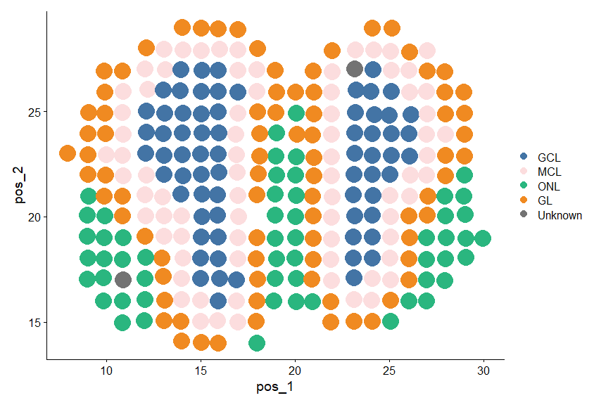

```r
Idents(MOB_ST) <- factor(MOB_ST$manual_annotation, levels = celltypes_manual)
DimPlot(MOB_ST, reduction = "pos", cols = cols_manual, pt.size = 8)
```

Then, we visualize the CAESAR annotation without account for ‘unassigned’.

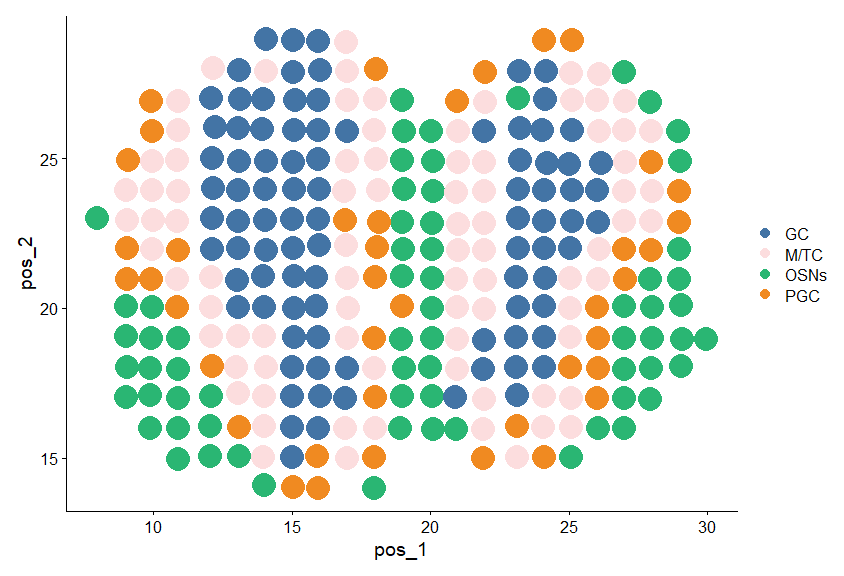

```r
Idents(MOB_ST) <- factor(MOB_ST$CAESAR, levels = celltypes)
DimPlot(MOB_ST, reduction = "pos", cols = cols, pt.size = 8)
```

And visualize the CAESAR annotation account for ‘unassigned’.

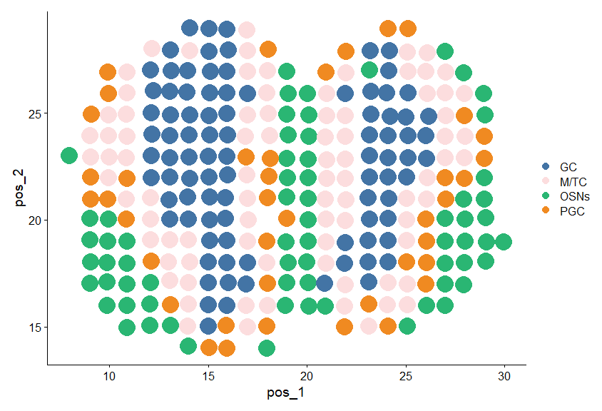

```r
Idents(MOB_ST) <- factor(MOB_ST$CAESARunasg, levels = celltypes)
DimPlot(MOB_ST, reduction = "pos", cols = cols, pt.size = 8)
```

The confidence level of the CAESAR annotation can be visualized by

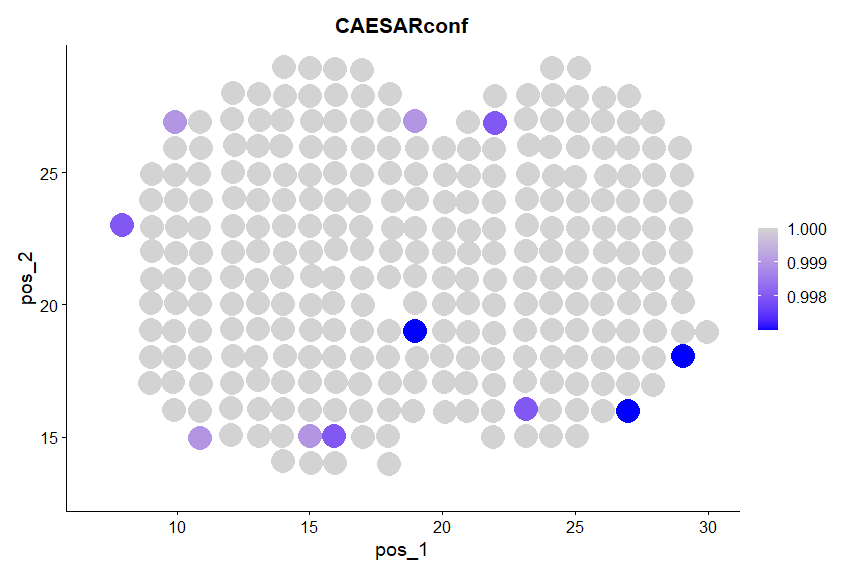

```r
FeaturePlot(
    MOB_ST,
    reduction = "pos", features = "CAESARconf", pt.size = 8,
    cols = c("blue", "lightgrey"), min.cutoff = 0.0, max.cutoff = 1.0
)
```

CAESAR provides the cell mixing proportion for each cell type, which can be visualized by

```r
caesar_prob <- colnames(MOB_ST@meta.data)[15:19]
print(caesar_prob)
```

```
#> [1] "prob_EPL.IN" "prob_GC"     "prob_M.TC"   "prob_OSNs"   "prob_PGC"
```

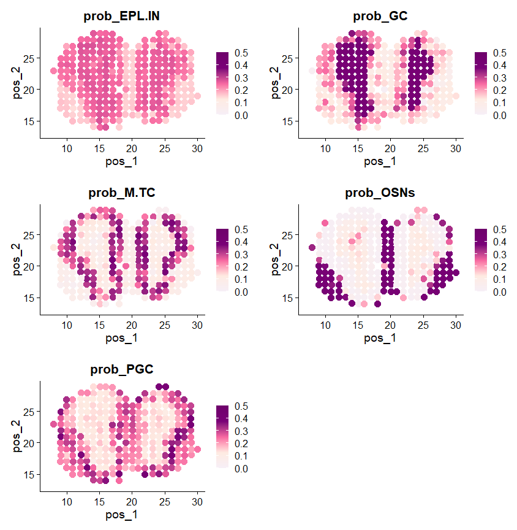

```r
plots <- lapply(caesar_prob, function(feature) {
    FeaturePlot(MOB_ST, features = feature, reduction = "pos", pt.size = 3.5) +
        scale_color_gradientn(
            colors = c("#f6eff7", "#feebe2", "#f768a1", "#7a0177", "#6e016b"),
            values = scales::rescale(c(0.0, 0.125, 0.25, 0.375, 0.50)),
            limits = c(0.0, 0.50)
        ) + labs(title = feature)
})
cowplot::plot_grid(plotlist = plots, ncol = 2)
```

The annotation accuracy is calculated by

```r
acc_st <- function(manual_annotation, pred) {
    manual_annotation <- as.character(manual_annotation)
    pred <- as.character(pred)
    manual_annotation[manual_annotation == "GCL"] <- "GC"
    manual_annotation[manual_annotation == "MCL"] <- "M/TC"
    manual_annotation[manual_annotation == "ONL"] <- "OSNs"
    manual_annotation[manual_annotation == "GL"] <- "PGC"
    return(mean(manual_annotation == pred))
}

print(paste0(
    "The ACC of CAESAR annotation is ",
    acc_st(MOB_ST$manual_annotation, MOB_ST$CAESARunasg)
))
```

```
#> [1] "The ACC of CAESAR annotation is 0.717857142857143"
```

Next, we detect and visualize the signature genes for each cell type.

```r
Idents(MOB_ST) <- factor(MOB_ST$CAESARunasg, celltypes)
sg_List <- find.sig.genes(MOB_ST)

str(sg_List)
```

```
#> List of 4
#>  $ GC  :'data.frame':    13895 obs. of  5 variables:
#>   ..$ distance        : num [1:13895] 5.49 5.49 5.52 5.53 5.56 ...
#>   ..$ expr.prop       : num [1:13895] 0.344 0.422 0.322 0.322 0.256 ...
#>   ..$ expr.prop.others: num [1:13895] 0.0842 0.0947 0.0579 0.0421 0.0421 ...
#>   ..$ label           : chr [1:13895] "GC" "GC" "GC" "GC" ...
#>   ..$ gene            : chr [1:13895] "Cdkn1a" "Rasgrp2" "Kcnh5" "Kcnh1" ...
#>  $ M/TC:'data.frame':    13895 obs. of  5 variables:
#>   ..$ distance        : num [1:13895] 6.69 6.74 6.74 6.75 6.75 ...
#>   ..$ expr.prop       : num [1:13895] 0.3494 0.0964 0.6627 0.7711 0.3012 ...
#>   ..$ expr.prop.others: num [1:13895] 0.1066 0.0152 0.2792 0.3147 0.1015 ...
#>   ..$ label           : chr [1:13895] "M/TC" "M/TC" "M/TC" "M/TC" ...
#>   ..$ gene            : chr [1:13895] "Raver2" "Slc16a10" "Zfp804a" "Nefl" ...
#>  $ OSNs:'data.frame':    13895 obs. of  5 variables:
#>   ..$ distance        : num [1:13895] 9.69 9.72 9.73 9.73 9.73 ...
#>   ..$ expr.prop       : num [1:13895] 0.836 0.448 0.612 0.701 0.493 ...
#>   ..$ expr.prop.others: num [1:13895] 0.2582 0.0892 0.1643 0.1315 0.1174 ...
#>   ..$ label           : chr [1:13895] "OSNs" "OSNs" "OSNs" "OSNs" ...
#>   ..$ gene            : chr [1:13895] "Hmgcs2" "Alx4" "Afap1l2" "Igfbp4" ...
#>  $ PGC :'data.frame':    13895 obs. of  5 variables:
#>   ..$ distance        : num [1:13895] 7.71 7.74 7.74 7.77 7.77 ...
#>   ..$ expr.prop       : num [1:13895] 0.55 0.825 0.6 0.35 0.5 0.075 0.375 0.2 0.1 0.85 ...
#>   ..$ expr.prop.others: num [1:13895] 0.183 0.412 0.267 0.188 0.192 ...
#>   ..$ label           : chr [1:13895] "PGC" "PGC" "PGC" "PGC" ...
#>   ..$ gene            : chr [1:13895] "Cnr1" "AI593442" "Shisa6" "Kcnj12" ...
```

We visualize the top three signature genes by a dot plot.

```r
# obtain the top three signature genes
celltypes_plot <- setdiff(names(sg_List), "unassigned")
top3sgs <- Intsg(list(sg_List), 3)[celltypes_plot]
print(top3sgs)
```

```
#> $GC
#> [1] "Cdkn1a"  "Rasgrp2" "Kcnh5"
#>
#> $`M/TC`
#> [1] "Raver2"  "Zfp804a" "Nefl"
#>
#> $OSNs
#> [1] "Hmgcs2"  "Alx4"    "Afap1l2"
#>
#> $PGC
#> [1] "Cnr1"     "AI593442" "Shisa6"
```

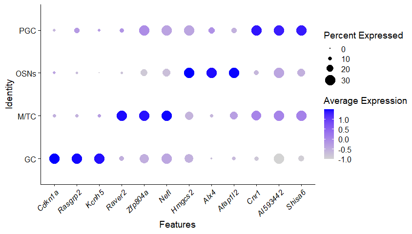

```r
sg_features <- unname(unlist(top3sgs))

DotPlot(
    MOB_ST,
    idents = celltypes_plot, col.min = -1, col.max = 2, dot.scale = 7,
    features = sg_features, scale.min = 0, scale.max = 30
) + theme(axis.text.x = element_text(face = "italic", angle = 45, vjust = 1, hjust = 1))
```

Next, we calculate the UMAP projections of co-embeddings of cells and the selected signature genes.

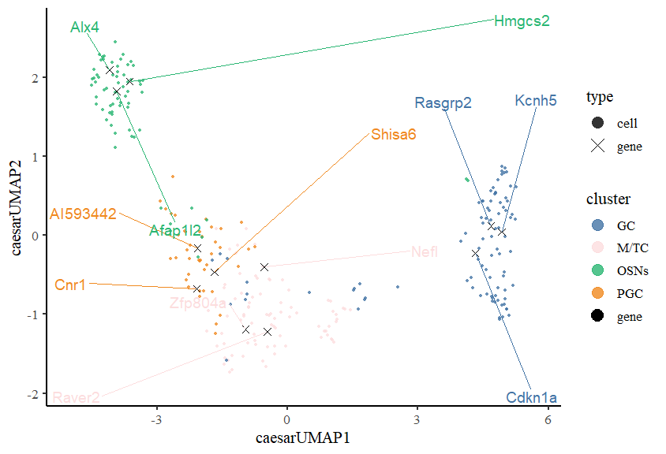

[output not shown]

[output cut: 108 more lines]

```r
# calculate coumap
MOB_ST <- CoUMAP(
    MOB_ST, reduction = "caesar", reduction.name = "caesarUMAP",
    gene.set = sg_features
)

df_gene_label <- data.frame(
    gene = unlist(top3sgs),
    label = rep(names(top3sgs), each = 3)
)

CoUMAP.plot(
    MOB_ST, reduction = "caesarUMAP", gene_txtdata = df_gene_label,
    cols = c("gene" = "#000000", cols)
)
```